# 第十讲：仿生优化算法

```matlab
graphics_toolkit('gnuplot')   % 在Octave的GUI界面或者MATLAB界面下不需要设置此项 %gnuplot
```

## 三、一个应用案例：时空装配线优化问题

### 3.1 贪婪算法 GRASP.m

```matlab
load('weemag.mat');
```

每一个方法执行前请重新执行下面这一段“初始化”代码片段

```matlab
outputm=[];
outputa=[];
totaliteration=100;
maxiteration=200;
test=0;

successor=zeros(notask);
for i=1:size(precs,1)
    a=unique([successor(:,precs(i,2))' successor(:,precs(i,1))' precs(i,1)]);
    successor(1:size(a,2),precs(i,2))=a;
end
Ej=ones(1,notask);
Lj=boundsstations(2)*ones(1,notask);
for i=1:notask  %计算最早最晚站
    Lj(i)=Lj(i)-sum(sum(successor==i));
    Ej(i)=length(unique(successor(:,i)));
end
```

开始贪婪法循环

```matlab
for main=1:totaliteration
%% 数据输入
    gamma=rand;
    x=zeros(notask);
    x1=x;
    precs2=precs;
    n=notask;
    k=1;
    data1=data;
    list=1:notask;
    stationlist=1:boundsstations(2);
%% 生成随机贪婪解
    result=[];
    for repeat=1:notask-1
        successor=zeros(notask);
        for i=1:size(precs2,1)
            a=unique([successor(:,precs2(i,2))' successor(:,precs2(i,1))' precs2(i,1)]);
            successor(1:size(a,2),precs2(i,2))=a;
        end
        a=zeros(notask,1);
        for i=list
            a(i)=n-size(unique(successor(:,i)),1);
        end
        a=a/max(a);
        nj=data(:,1)/sum(data(:,1)).*data(:,2)/sum(data(:,2)).*a;
        if sum(nj)==0
            nj(list)=nj(list)+1;
        end
        nj=nj/sum(nj);   %计算启发值nj
        [njsorted,njorder]=sort(nj,'descend');
        q=max(nj)-gamma*(max(nj)-min(nj));
        RCL=njorder(njsorted>=q);
        j=RCL(randi(length(RCL)),1);    %选出任务分配到当前站
        result=[result,j];
        tempostation=Ej(j);
        x(j,tempostation)=1;
        while ~ismember(tempostation,stationlist)||x(:,tempostation)'*data(:,1)>cycletime
            x(j,tempostation)=0;
            tempostation=tempostation+1;
            x(j,tempostation)=1;
        end

        if rand<=x(:,tempostation)'*data(:,1)/cycletime
            stationlist=stationlist(stationlist~=tempostation);

        end     %判断是否关闭当前站
        n=n-1;      %去掉数据
        list=list(~ismember(list,j));
        precs2=precs2(precs2(:,1)~=j,:);
    end
    tempostation=Ej(list);
    while ~ismember(tempostation,stationlist)
        tempostation=tempostation+1;
    end
    x(list,tempostation)=1;
    result=[result,list];
%% 局部搜索
    lamda1=rand;
    lamda2=1-lamda1;
    min1=lamda1*sum(max(x))+lamda2*max(data(:,2)'*x);
    min2=min1;
    x1=x;
    if lamda1>=lamda2       %A局部搜索
        for iteration=1:maxiteration
            min1=lamda1*sum(max(x))+lamda2*max(data(:,2)'*x);
            min2=min1;
            [m,index]=max(data(:,2)'*x);
            tasks=find(x(:,index)==1);
            while min2>=min1&&~isempty(tasks)
                task=tasks(1);
                targetstation=index;
                logic1=0;
                logic2=0;
                while logic1==0&&logic2<20
                    areainfo=data(:,2)'*x1;
                    areainfo=areainfo(Ej(task):Lj(task));
                    [minstation,postation]=min(areainfo(areainfo~=0));
                    postation=postation+Ej(task)-1;
                    x1(task,targetstation)=0;
                    x1(task,postation)=1;
                    targetstation=postation;
                    min2=lamda1*sum(max(x1))+lamda2*max(data(:,2)'*x1);
                    if min2<min1
                        x=x1;
                        logic1=1;
                    end
                    logic2=logic2+1;
                end
                tasks=tasks(tasks~=task);
            end
        end
    else                %m局部搜索
        for iteration=1:maxiteration
            [stationsorted,stationorder]=sort(sum(x),'descend');
            maxstation=length(stationorder);
            i=1;
            logic=1;
            while i<maxstation&&min2>=min1&&logic
                targetstation=stationorder(i);
                setoftasks=find(x(:,targetstation)==1);
                task=setoftasks(1);
                x2=x1;
                distribution=targetstation;
                for r=Ej(task):Lj(task)
                    x2(task,distribution)=0;
                    x2(task,r)=1;
                    min3=lamda1*sum(max(x2))+lamda2*max(data(:,2)'*x2);
                    min4=lamda1*sum(max(x1))+lamda2*max(data(:,2)'*x1);
                    distribution=r;
                    if min3<min4
                        x1=x2;
                    else
                    end
                end
                setoftasks=setoftasks(setoftasks~=task);
                if isempty(setoftasks)
                    logic=0;
                else
                end
                min2=lamda1*sum(max(x1))+lamda2*max(data(:,2)'*x1);
                min1=lamda1*sum(max(x))+lamda2*max(data(:,2)'*x);
                if min2>=min1
                    i=i+1;
                else
                    x=x1;
                end
            end
        end
    end

%% 计算结果
    outputm=[outputm,sum(max(x))];
    outputa=[outputa,max(data(:,2)'*x)];
end
```

```matlab
%% 帕累托前沿计算
paretom=sort(unique(outputm),'ascend');
paretoa=zeros(1,length(paretom));
for i=1:length(paretom)
    paretoa(i)=min(outputa(outputm==paretom(i)));
end
for i=1:length(paretom)
    for j=1:i
        if paretoa(i)>=paretoa(j)&&paretom(i)>=paretom(j)
            paretoa(i)=paretoa(j);
            paretom(i)=paretom(j);
        end
    end
end
pareto=[paretoa;paretom]';
pareto=unique(pareto,'rows');
paretoa=pareto(:,1);
paretom=pareto(:,2);
```

```matlab
outputm
```

[output not shown]

```matlab
scatter(outputm,outputa,30, 'b', "filled");
```

[output not shown]

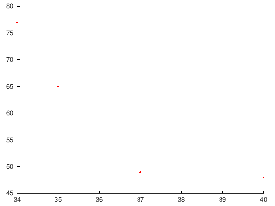

```matlab
scatter(paretom,paretoa,30, 'r','filled');
```

### 3.2 蚁群算法 ant.m

注意，这里先执行3.1中的“初始化代码”。 然后开始蚁群算法的初始化部分：

```matlab
f0 = @(x) sum(max(x));
f1 = @(x,data) max(data(:,2)'*x);
```

```matlab
S=zeros(notask);  %计算tau0
x1=S;
x2=S;
successor=zeros(notask);
for i=1:size(precs,1)
    a=unique([successor(:,precs(i,2))' successor(:,precs(i,1))' precs(i,1)]);
    successor(1:size(a,2),precs(i,2))=a;
end
a=zeros(notask,1);
for i=1:notask
    a(i)=notask-size(unique(successor(:,i)),1);
end
a=a/max(a);
n0=data(:,1)/cycletime.*a;
n1=data(:,1)/sum(data(:,1)).*a;
st1=1;
st2=1;
for i=1:notask
    [a1,a2]=max(n0);
    [b1,b2]=max(n1);
    if i==1
        list1=a2;
        list2=b2;
    else
        list1=[list1,a2];
        list2=[list2,b2];
    end
    if sum(data([list1],1))>cycletime
        list1=a2;
        st1=st1+1;
    end
    if sum(data([list2],1))>cycletime
        list2=a2;
        st2=st2+1;
    end
    n0(a2)=0;
    n1(b2)=0;
    x1(a2,st1)=1;
    x2(b2,st2)=1;
end
tau0=1/(f0(x1)*f1(x2,data));
n0=data(:,1)/cycletime.*a;
n1=data(:,1)/sum(data(:,1)).*a;
S=x1;
tau=zeros(notask);
for i=1:notask
    for j=Ej(i):Lj(i)
        tau(j,i)=1;
    end
end
tau=tau/sum(sum(tau));
```

计算帕累托最优

```matlab
paretom=sort(unique(outputm),'ascend');
paretoa=zeros(1,length(paretom));
for i=1:length(paretom)
    paretoa(i)=min(outputa(outputm==paretom(i)));
end
for i=1:length(paretom)
    for j=1:i
        if paretoa(i)>=paretoa(j)&&paretom(i)>=paretom(j)
            paretoa(i)=paretoa(j);
            paretom(i)=paretom(j);
        end
    end
end
pareto=[paretoa;paretom]';
pareto=unique(pareto,'rows');
paretoa=pareto(:,1);
paretom=pareto(:,2);
```

```matlab
scatter(outputm,outputa,30,"red","filled");
hold on;
scatter(paretom,paretoa,30,"blue","filled");
```

[output not shown]

### 3.3 遗传算法 gen.m

```matlab
% 暂不提供
```